# UNIVESP - Projeto Integrador (2024)

Disciplina: **Projeto Integrador em Computação IV – PJI410**

Grupo: **DRP01-PJI410-SALA001-GRP017**

Período: 2º Semestre de 2024

Tema: Desenvolver um painel com informações relevantes para avaliação dos principais fatores de riscos que causam a hipertensão, utilizando análise descritiva e preditiva.

Problema: A hipertensão, segundo o Ministério da Saúde do Brasil, é uma doença crônica caracterizada por níveis elevados da pressão sanguínea nas artérias, ou seja, o coração é obrigado a exercer um esforço maior do que o normal para fazer com que o sangue seja distribuído de forma regular pelo corpo. A hipertensão é caracterizada quando os valores da pressão arterial sistólica ou diastólica (máxima e mínima) são iguais ou superiores a 140/90 mmHg (popularmente 14 por 9). É um dos principais fatores de risco para a ocorrência de acidente vascular cerebral, enfarte, aneurisma arterial e insuficiência renal e cardíaca. Em 90% dos casos a hipertensão é herdada dos pais, mas há vários fatores que podem influenciar os níveis de pressão arterial, como: fumo; consumo de bebidas alcoólicas; obesidade; estresse; elevado consumo de sal; níveis altos de colesterol e falta de atividade física. Além desses fatores de risco, sabe-se que a incidência da pressão alta é maior na raça negra, em diabéticos, e aumenta com a idade.

Objetivo geral: desenvolver um painel com informações relevantes para avaliação e simulação da influência dos principais fatores de riscos que causam a hipertensão, utilizando análise descritiva e preditiva com apoio de ferramentas e softwares estatísticos baseados em *R* e *RStudio*. O painel foi desenvolvido usando os recursos da ferramenta *Quarto*.

Etapas realizadas:

- Coleta dos dados na plataforma *Kaggle* (*UCI*);
- Realização de um pré-processamento dos dados;
- Preparação dos dados para as análises, verificando a presença de dados faltantes e atípicos;
- Realização de uma análise visual dos dados;
- Extração de informações demográficas com base nos dados;
- Verificação do relacionamento das variáveis com base em aspectos da hipertensão;
- Mapeamento do número de pessoas que apresentam níveis de hipertensão e suas características demográficas;
- Aplicação dos algoritmos de classificação (regressão logística, *naive Bayes* e *random forest*) para a predição dos fatores de riscos em relação à hipertensão;
- Implantação e disponibilizção de um painel na Internet.

Público Total

68205

Público Feminino

65%

Público Masculino

35%

**Feminino**

**Idade**

```
                    Idade
----------------- -------
            Média   52.94
      Desv.padrão    6.67
              Mín   29.00
              Máx   64.00
```

**PA-sistólica**

```
                    PA_Sis
----------------- --------
            Média   125.73
      Desv.padrão    16.08
              Mín    90.00
              Máx   180.00
```

**PA-diastólica**

```
                    PA_Dia
----------------- --------
            Média    80.82
      Desv.padrão     9.21
              Mín    60.00
              Máx   120.00
```

**IMC**

```
                       IMC
----------------- --------
            Média    27.94
      Desv.padrão     6.43
              Mín     8.00
              Máx   298.67
```

**Masculino**

**Idade**

```
                    Idade
----------------- -------
            Média   52.60
      Desv.padrão    6.95
              Mín   29.00
              Máx   64.00
```

**PA-sistólica**

```
                    PA_Sis
----------------- --------
            Média   127.76
      Desv.padrão    15.65
              Mín    90.00
              Máx   180.00
```

**PA-diastólica**

```
                    PA_Dia
----------------- --------
            Média    82.09
      Desv.padrão     8.96
              Mín    60.00
              Máx   120.00
```

**IMC**

```
                       IMC
----------------- --------
            Média    26.72
      Desv.padrão     5.09
              Mín     3.47
              Máx   180.68
```

Distribuição das pessoas por níveis de hipertensão

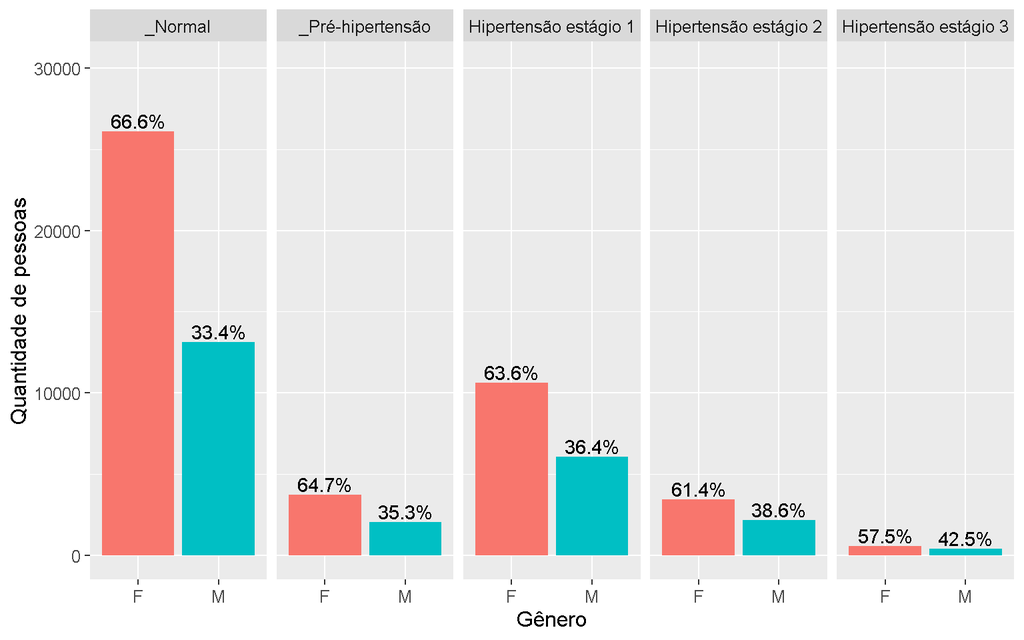

Distribuição das pessoas por sexo e faixa etária

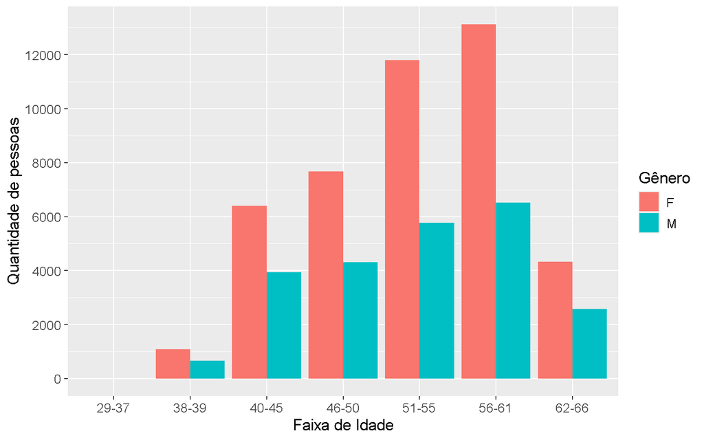

Distribuição das pessoas por sexo e fatores de risco

| Características | **F** N = 44,427 | **M** N = 23,778 |
| --- | --- | --- |
| - Colesterol |  |  |
| _Normal | 32,854 (74%) | 18,368 (77%) |
| Alto | 6,184 (14%) | 3,007 (13%) |
| Elevado | 5,389 (12%) | 2,403 (10%) |
| - Classificação da PA |  |  |
| _Normal | 26,119 (59%) | 13,112 (55%) |
| _Pré-hipertensão | 3,711 (8.4%) | 2,028 (8.5%) |
| Hipertensão estágio 1 | 10,618 (24%) | 6,079 (26%) |
| Hipertensão estágio 2 | 3,421 (7.7%) | 2,147 (9.0%) |
| Hipertensão estágio 3 | 558 (1.3%) | 412 (1.7%) |
| - Níveis de glicose |  |  |
| _Normal | 37,570 (85%) | 20,457 (86%) |
| Alta | 3,305 (7.4%) | 1,693 (7.1%) |
| Elevada | 3,552 (8.0%) | 1,628 (6.8%) |
| - Fumante |  |  |
| Fumante | 790 (1.8%) | 5,189 (22%) |
| Não fumante | 43,637 (98%) | 18,589 (78%) |
| - Álcool |  |  |
| Consome | 1,116 (2.5%) | 2,508 (11%) |
| Não consome | 43,311 (97%) | 21,270 (89%) |
| - Atividade física |  |  |
| Não prática | 8,795 (20%) | 4,604 (19%) |
| Prática | 35,632 (80%) | 19,174 (81%) |

**Tabelas de contingência em relação à classificação da Pressão Arterial (PA)**

*Feminino*

**PA x Colesterol**

```
----------------------- ------------ --------------- -------------- -------------- ----------------
                          Colesterol          Normal           Alto        Elevado            Total
       Classificação PA
                 Normal                21445 (48.3%)   2897 ( 6.5%)   1777 ( 4.0%)   26119 ( 58.8%)
        Pré-hipertensão                 2442 ( 5.5%)    525 ( 1.2%)    744 ( 1.7%)    3711 (  8.4%)
  Hipertensão estágio 1                 6639 (14.9%)   1885 ( 4.2%)   2094 ( 4.7%)   10618 ( 23.9%)
  Hipertensão estágio 2                 2023 ( 4.6%)    746 ( 1.7%)    652 ( 1.5%)    3421 (  7.7%)
  Hipertensão estágio 3                  305 ( 0.7%)    131 ( 0.3%)    122 ( 0.3%)     558 (  1.3%)
                  Total                32854 (74.0%)   6184 (13.9%)   5389 (12.1%)   44427 (100.0%)
----------------------- ------------ --------------- -------------- -------------- ----------------
```

**PA x Glicose**

```
----------------------- --------- --------------- ------------- ------------- ----------------
                          Glicose          Normal          Alta       Elevada            Total
       Classificação PA
                 Normal             23017 (51.8%)   1504 (3.4%)   1598 (3.6%)   26119 ( 58.8%)
        Pré-hipertensão              2933 ( 6.6%)    328 (0.7%)    450 (1.0%)    3711 (  8.4%)
  Hipertensão estágio 1              8538 (19.2%)    959 (2.2%)   1121 (2.5%)   10618 ( 23.9%)
  Hipertensão estágio 2              2680 ( 6.0%)    425 (1.0%)    316 (0.7%)    3421 (  7.7%)
  Hipertensão estágio 3               402 ( 0.9%)     89 (0.2%)     67 (0.2%)     558 (  1.3%)
                  Total             37570 (84.6%)   3305 (7.4%)   3552 (8.0%)   44427 (100.0%)
----------------------- --------- --------------- ------------- ------------- ----------------
```

**PA x Fumante**

```
----------------------- --------- --------------- ------------- ----------------
                          Fumante             Não           Sim            Total
       Classificação PA
                 Normal             25677 (57.8%)   442 (0.99%)   26119 ( 58.8%)
        Pré-hipertensão              3645 ( 8.2%)    66 (0.15%)    3711 (  8.4%)
  Hipertensão estágio 1             10416 (23.4%)   202 (0.45%)   10618 ( 23.9%)
  Hipertensão estágio 2              3357 ( 7.6%)    64 (0.14%)    3421 (  7.7%)
  Hipertensão estágio 3               542 ( 1.2%)    16 (0.04%)     558 (  1.3%)
                  Total             43637 (98.2%)   790 (1.78%)   44427 (100.0%)
----------------------- --------- --------------- ------------- ----------------
```

**PA x Álcool**

```
----------------------- -------- -------------- --------------- ----------------
                          Alcool        Consome     Não consome            Total
       Classificação PA
                 Normal             559 (1.26%)   25560 (57.5%)   26119 ( 58.8%)
        Pré-hipertensão             112 (0.25%)    3599 ( 8.1%)    3711 (  8.4%)
  Hipertensão estágio 1             318 (0.72%)   10300 (23.2%)   10618 ( 23.9%)
  Hipertensão estágio 2             103 (0.23%)    3318 ( 7.5%)    3421 (  7.7%)
  Hipertensão estágio 3              24 (0.05%)     534 ( 1.2%)     558 (  1.3%)
                  Total            1116 (2.51%)   43311 (97.5%)   44427 (100.0%)
----------------------- -------- -------------- --------------- ----------------
```

**PA x Atividade Física**

```
----------------------- ------------------ -------------- --------------- ----------------
                          Atividade Física    Não prática         Prática            Total
       Classificação PA
                 Normal                      5202 (11.7%)   20917 (47.1%)   26119 ( 58.8%)
        Pré-hipertensão                       766 ( 1.7%)    2945 ( 6.6%)    3711 (  8.4%)
  Hipertensão estágio 1                      2035 ( 4.6%)    8583 (19.3%)   10618 ( 23.9%)
  Hipertensão estágio 2                       677 ( 1.5%)    2744 ( 6.2%)    3421 (  7.7%)
  Hipertensão estágio 3                       115 ( 0.3%)     443 ( 1.0%)     558 (  1.3%)
                  Total                      8795 (19.8%)   35632 (80.2%)   44427 (100.0%)
----------------------- ------------------ -------------- --------------- ----------------
```

*Masculino*

**PA x Colesterol**

```
----------------------- ------------ --------------- -------------- -------------- ----------------
                          Colesterol          Normal           Alto        Elevado            Total
       Classificação PA
                 Normal                11230 (47.2%)   1123 ( 4.7%)    759 ( 3.2%)   13112 ( 55.1%)
        Pré-hipertensão                 1425 ( 6.0%)    263 ( 1.1%)    340 ( 1.4%)    2028 (  8.5%)
  Hipertensão estágio 1                 4127 (17.4%)   1077 ( 4.5%)    875 ( 3.7%)    6079 ( 25.6%)
  Hipertensão estágio 2                 1351 ( 5.7%)    443 ( 1.9%)    353 ( 1.5%)    2147 (  9.0%)
  Hipertensão estágio 3                  235 ( 1.0%)    101 ( 0.4%)     76 ( 0.3%)     412 (  1.7%)
                  Total                18368 (77.2%)   3007 (12.6%)   2403 (10.1%)   23778 (100.0%)
----------------------- ------------ --------------- -------------- -------------- ----------------
```

**PA x Glicose**

```
----------------------- --------- --------------- ------------- ------------- ----------------
                          Glicose          Normal          Alta       Elevada            Total
       Classificação PA
                 Normal             11688 (49.2%)    703 (3.0%)    721 (3.0%)   13112 ( 55.1%)
        Pré-hipertensão              1674 ( 7.0%)    143 (0.6%)    211 (0.9%)    2028 (  8.5%)
  Hipertensão estágio 1              5059 (21.3%)    535 (2.2%)    485 (2.0%)    6079 ( 25.6%)
  Hipertensão estágio 2              1715 ( 7.2%)    263 (1.1%)    169 (0.7%)    2147 (  9.0%)
  Hipertensão estágio 3               321 ( 1.3%)     49 (0.2%)     42 (0.2%)     412 (  1.7%)
                  Total             20457 (86.0%)   1693 (7.1%)   1628 (6.8%)   23778 (100.0%)
----------------------- --------- --------------- ------------- ------------- ----------------
```

**PA x Fumante**

```
----------------------- --------- --------------- -------------- ----------------
                          Fumante             Não            Sim            Total
       Classificação PA
                 Normal             10418 (43.8%)   2694 (11.3%)   13112 ( 55.1%)
        Pré-hipertensão              1525 ( 6.4%)    503 ( 2.1%)    2028 (  8.5%)
  Hipertensão estágio 1              4695 (19.7%)   1384 ( 5.8%)    6079 ( 25.6%)
  Hipertensão estágio 2              1638 ( 6.9%)    509 ( 2.1%)    2147 (  9.0%)
  Hipertensão estágio 3               313 ( 1.3%)     99 ( 0.4%)     412 (  1.7%)
                  Total             18589 (78.2%)   5189 (21.8%)   23778 (100.0%)
----------------------- --------- --------------- -------------- ----------------
```

**PA x Álcool**

```
----------------------- -------- -------------- --------------- ----------------
                          Alcool        Consome     Não consome            Total
       Classificação PA
                 Normal            1218 ( 5.1%)   11894 (50.0%)   13112 ( 55.1%)
        Pré-hipertensão             233 ( 1.0%)    1795 ( 7.5%)    2028 (  8.5%)
  Hipertensão estágio 1             708 ( 3.0%)    5371 (22.6%)    6079 ( 25.6%)
  Hipertensão estágio 2             295 ( 1.2%)    1852 ( 7.8%)    2147 (  9.0%)
  Hipertensão estágio 3              54 ( 0.2%)     358 ( 1.5%)     412 (  1.7%)
                  Total            2508 (10.5%)   21270 (89.5%)   23778 (100.0%)
----------------------- -------- -------------- --------------- ----------------
```

**PA x Atividade Física**

```
----------------------- ------------------ -------------- --------------- ----------------
                          Atividade Física    Não prática         Prática            Total
       Classificação PA
                 Normal                      2478 (10.4%)   10634 (44.7%)   13112 ( 55.1%)
        Pré-hipertensão                       432 ( 1.8%)    1596 ( 6.7%)    2028 (  8.5%)
  Hipertensão estágio 1                      1206 ( 5.1%)    4873 (20.5%)    6079 ( 25.6%)
  Hipertensão estágio 2                       401 ( 1.7%)    1746 ( 7.3%)    2147 (  9.0%)
  Hipertensão estágio 3                        87 ( 0.4%)     325 ( 1.4%)     412 (  1.7%)
                  Total                      4604 (19.4%)   19174 (80.6%)   23778 (100.0%)
----------------------- ------------------ -------------- --------------- ----------------
```

**Modelo Regressão Logística: variável alvo “cardio” (presença ou ausência de doenças cardiovasculares)**

Variáveis preditoras e o ajuste do modelo

```
# A tibble: 13 × 5
   term               estimate std.error statistic   p.value
   <chr>                 <dbl>     <dbl>     <dbl>     <dbl>
 1 (Intercept)        -11.5      0.138     -83.1   0
 2 genero_Masc          0.0305   0.0220      1.38  1.67e-  1
 3 idade                0.0517   0.00152    34.1   1.13e-254
 4 imc                  0.0193   0.00191    10.1   4.60e- 24
 5 PA_sis               0.0585   0.00106    55.0   0
 6 PA_dia               0.0112   0.00167     6.71  1.93e- 11
 7 colesterol_Alto      0.390    0.0308     12.7   8.52e- 37
 8 colesterol_Elevado   1.09     0.0399     27.2   5.99e-163
 9 glicose_Alta         0.0220   0.0407      0.539 5.90e-  1
10 glicose_Elevada     -0.334    0.0443     -7.53  5.12e- 14
11 fumante_Sim         -0.131    0.0392     -3.33  8.63e-  4
12 alcool_Sim          -0.229    0.0479     -4.77  1.85e-  6
13 ativFisic_Sim       -0.231    0.0245     -9.40  5.33e- 21
```

Razões de chances

```
# A tibble: 13 × 5
   term                estimate std.error statistic   p.value
   <chr>                  <dbl>     <dbl>     <dbl>     <dbl>
 1 (Intercept)        0.0000102   0.138     -83.1   0
 2 genero_Masc        1.03        0.0220      1.38  1.67e-  1
 3 idade              1.05        0.00152    34.1   1.13e-254
 4 imc                1.02        0.00191    10.1   4.60e- 24
 5 PA_sis             1.06        0.00106    55.0   0
 6 PA_dia             1.01        0.00167     6.71  1.93e- 11
 7 colesterol_Alto    1.48        0.0308     12.7   8.52e- 37
 8 colesterol_Elevado 2.96        0.0399     27.2   5.99e-163
 9 glicose_Alta       1.02        0.0407      0.539 5.90e-  1
10 glicose_Elevada    0.716       0.0443     -7.53  5.12e- 14
11 fumante_Sim        0.878       0.0392     -3.33  8.63e-  4
12 alcool_Sim         0.796       0.0479     -4.77  1.85e-  6
13 ativFisic_Sim      0.794       0.0245     -9.40  5.33e- 21
```

Matriz de confusão

```
          Truth
Prediction  Nao  Sim
       Nao 5484 2231
       Sim 1488 4472
```

Métricas de avaliação

```
# A tibble: 3 × 3
  .metric     .estimator .estimate
  <chr>       <chr>          <dbl>
1 accuracy    binary         0.728
2 specificity binary         0.667
3 sensitivity binary         0.787
```

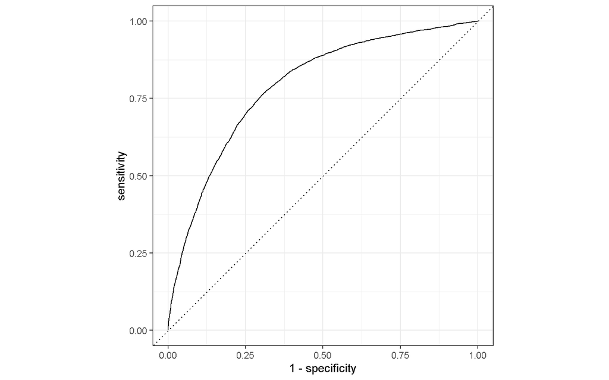

**Modelo *Naive Bayes*: variável alvo “cardio” (presença ou ausência de doenças cardiovasculares)**

Matriz de confusão

```
          Truth
Prediction  Nao  Sim
       Nao 5679 2506
       Sim 1293 4197
```

Métricas de avaliação

```
# A tibble: 3 × 3
  .metric     .estimator .estimate
  <chr>       <chr>          <dbl>
1 accuracy    binary         0.722
2 specificity binary         0.626
3 sensitivity binary         0.815
```

**Modelo *Random Forest*: variável alvo “cardio” (presença ou ausência de doenças cardiovasculares)**

```
Call:
 randomForest(formula = cardio ~ genero_ + idade + imc + PA_sis +      PA_dia + colesterol_ + glicose_ + fumante_ + alcool_ + ativFisic_,      data = cardioData_train, ntree = 200, mtry = 5)
               Type of random forest: classification
                     Number of trees: 200
No. of variables tried at each split: 5

        OOB estimate of  error rate: 28.59%
Confusion matrix:
      Nao   Sim class.error
Nao 20664  6897   0.2502449
Sim  8695 18274   0.3224072
```

```
Confusion Matrix and Statistics


pred_test  Nao  Sim
      Nao 5243 2148
      Sim 1729 4555

               Accuracy : 0.7165
                 95% CI : (0.7089, 0.724)
    No Information Rate : 0.5098
    P-Value [Acc > NIR] : < 0.00000000000000022

                  Kappa : 0.4321

 Mcnemar's Test P-Value : 0.00000000001904

            Sensitivity : 0.7520
            Specificity : 0.6795
         Pos Pred Value : 0.7094
         Neg Pred Value : 0.7249
             Prevalence : 0.5098
         Detection Rate : 0.3834
   Detection Prevalence : 0.5405
      Balanced Accuracy : 0.7158

       'Positive' Class : Nao
```